# Loan Data Exploration

### 4.6 Loan’s outcome status vs debt-to-income ratio

```python
df_status.groupby('Status')['DebtToIncomeRatio'].mean()
```

```
Status
Completed    0.233620
Defaulted    0.273061
Name: DebtToIncomeRatio, dtype: float64
```

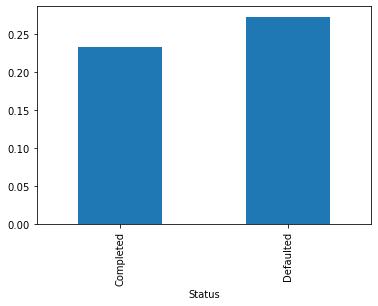

```python
df_status.groupby('Status')['DebtToIncomeRatio'].mean().plot(kind='bar');
```

People who completed the loan payments have lower debt-to-income ratios than those who defaulted.

### 4.7 Loan’s outcome status vs Credit Score

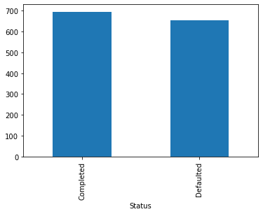

```python
df_status.groupby('Status')['CreditScore'].mean().plot(kind='bar');
```

People who completed the loan payments have higher credit scores than those who defaulted.

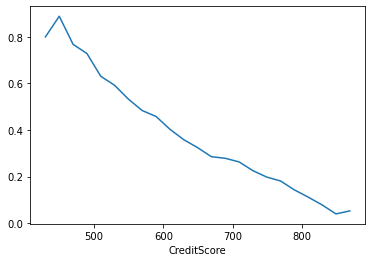

```python
# generate data of 'Status', 'CreditScore'
credit_defaulted = df_status.groupby(['Status', 'CreditScore'])['Status'].count().unstack(0)

credit_defaulted_rate = (credit_defaulted['Defaulted'] / (credit_defaulted['Defaulted'] + credit_defaulted['Completed']))
credit_defaulted_rate.plot();
```

The higher the credit score, the lower the defaulted rate.

### 4.8 Loan’s outcome status vs Prosper rating

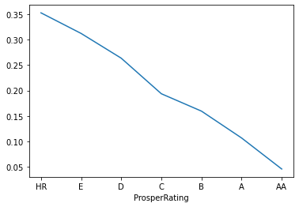

```python
# generate data of 'Status', 'ProsperRating'
prosper_defaulted = df_status.groupby(['Status', 'ProsperRating'])['Status'].count().unstack(0)

prosper_defaulted_rate = (prosper_defaulted['Defaulted'] / (prosper_defaulted['Defaulted'] + prosper_defaulted['Completed']))
prosper_defaulted_rate.plot();
```

The higher the Prosper rating, the lower the defaulted rate.

### 4.9 Loan’s outcome status vs Delinquencies Last 7 Years

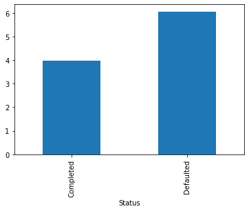

```python
df_status.groupby('Status')['DelinquenciesLast7Years'].mean().plot(kind='bar');
```

People who completed the loan payments have less Delinquencies Last 7 Years than those who defaulted.

```python
# generate a variable indicating DelinquenciesLast7Years to 0 or >0
df_status.loc[df_status.DelinquenciesLast7Years>0,'IfDelinquencies']= True
df_status.loc[df_status.DelinquenciesLast7Years==0,'IfDelinquencies']= False
```

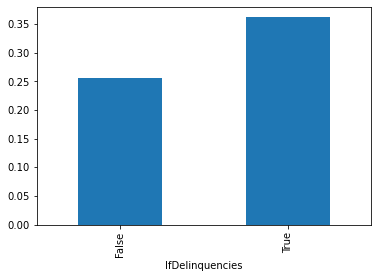

```python
# generate data of 'Status', 'ProsperRating'
delinquencies_defaulted = df_status.groupby(['Status', 'IfDelinquencies'])['Status'].count().unstack(0)

delinquencies_defaulted_rate = (delinquencies_defaulted['Defaulted'] / (delinquencies_defaulted['Defaulted'] + delinquencies_defaulted['Completed']))
delinquencies_defaulted_rate.plot(kind='bar');
```

People who have no delinquencies have a lower defaulted rate than those who have delinquencies.

### Talk about some of the relationships you observed in this part of the investigation. How did the feature(s) of interest vary with other features in the dataset?

- **Loan status**: The defaulted rate is correlated with Delinquencies Last 7 Years, prosper rating, credit score, debt-to-income ratio and income range.
- **Borrower rate**: The borrower rate is correlated with debt-to-income ratio and prosper rating.

### Did you observe any interesting relationships between the other features (not the main feature(s) of interest)?

- Income indicators seems correlated with each other, namely IncomeRange, IsBorrowerHomeowner, StatedMonthlyIncome and ProsperRating.

## 5. Multivariate Exploration

### 5.1 Borrower Rate, loan amount and terms

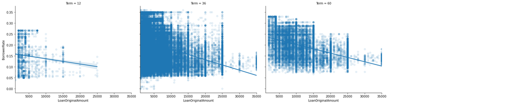

```python
# BorrowerRate, loan amount and terms
g=sns.FacetGrid(data=df, aspect=1.2, height=5, col='Term', col_wrap=4)
g.map(sns.regplot, 'LoanOriginalAmount', 'BorrowerRate', x_jitter=0.04, scatter_kws={'alpha':0.1});
g.add_legend();
```

Term may not impact the relationship between borrower rate and original loan amount

### 5.2 Borrower Rate, Prosper Rating and terms

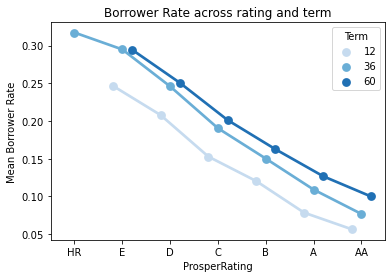

```python
ax = sns.pointplot(data = df, x = 'ProsperRating', y = 'BorrowerRate', hue = 'Term',
           palette = 'Blues', dodge = 0.4)
plt.title('Borrower Rate across rating and term')
plt.ylabel('Mean Borrower Rate')
ax.set_yticklabels([],minor = True);
```

### 5.3 Borrower Rate, Credit Score and terms

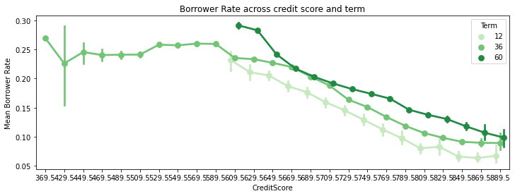

```python
fig = plt.figure(figsize = [12,4])
ax = sns.pointplot(data = df, x = 'CreditScore', y = 'BorrowerRate', hue = 'Term',
           palette = 'Greens', dodge = 0.4)
plt.title('Borrower Rate across credit score and term')
plt.ylabel('Mean Borrower Rate')
ax.set_yticklabels([],minor = True);
```

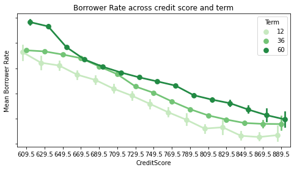

```python
df_credit_group = df[df['CreditScore']>600]

fig = plt.figure(figsize = [8,4])
ax = sns.pointplot(data = df_credit_group, x = 'CreditScore', y = 'BorrowerRate', hue = 'Term',
           palette = 'Greens', dodge = 0.4)
plt.title('Borrower Rate across credit score and term')
plt.ylabel('Mean Borrower Rate')
ax.set_yticklabels([],minor = False);
```

### 5.4 Loan Original Amount, Prosper Rating and terms

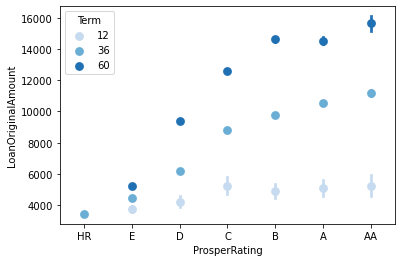

```python
sns.pointplot(data = df, x = 'ProsperRating', y = 'LoanOriginalAmount', hue = 'Term',
           palette = 'Blues', linestyles = '');
```

People with higher prosper rating (D to AA) could get higher amount of loan for longer term compared to those with low prosper rating (HR to E).

### 5.5 Loan Original Amount, Credit Score and terms

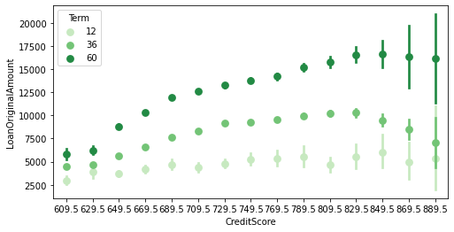

```python
# using data with credit score above 560 to plot
fig = plt.figure(figsize = [8,4])
sns.pointplot(data = df_credit_group, x = 'CreditScore', y = 'LoanOriginalAmount', hue = 'Term',
           palette = 'Greens', linestyles = '');
```

Generally, people with higher credit score could get higher amount of loan for longer term compared to those with low cedit score.